# PLSC30500, Fall 2024

Part 3. Learning from random samples (part b)

Andy Eggers

## Recapping

Say our **estimand** $\theta$ is a population mean, i.e. ${\textrm E}[X]$

We have a **plug-in estimator** $\hat{\theta}$, the sample mean $\overline{X}_{(n)}$.

$\overline{X}$ has a **sampling distribution**. What do we know about it?

- centered on ${\textrm E}[X]$, i.e. **unbiased**: ${\textrm E}[\overline{X}] = {\textrm E}[X]$
- variance is ${\textrm V}[X]/n$, which we can approximate with $\hat{V}[X]/n$
- by CLT, **asymptotically normal**

What can we do with this knowledge?

## All-knowing perspective

Suppose we knew ${\textrm E}[X]$ and ${\textrm V}[X]$.

Then we know the *asymptotic* sampling distribution of $\overline{X}$, i.e. $N\left({\textrm E}[X], \frac{{\textrm V}[X]}{n}\right)$.

We could then compute, e.g. the probability of observing a sample mean below 2 if ${\textrm E}[X] = 2.104$, ${\textrm V}[X] = 4.63$, and $n = 198$.

```r
pnorm(q = 2, mean = 2.104, sd = sqrt(4.63/198))
```

```
[1] 0.2482193
```

Similar if we only knew ${\textrm E}[X]$ but not ${\textrm V}[X]$.

## The researcher’s perspective

But we don’t know ${\textrm E}[X]$ (that’s why we’re doing research).

We have an estimate $\overline{X}$, and we can estimate ${\textrm V}[X]$ from the sample. What more can we say about ${\textrm E}[X]$?

Reporting $\hat{\sigma}[\overline{X}] = \sqrt{\frac{\hat{{\textrm V}}[X]}{n}}$, the **standard error**, is a start.

Approaches we will take:

- what is an interval centered on $\overline{X}$ that will contain ${\textrm E}[X]$ in at least 95% of samples? (**confidence interval**)
- suppose ${\textrm E}[X] = c$. what is the probability of observing $\overline{X}$ at least as far from $c$ as what we observed? (**p-value**)

## The researcher’s perspective (2)

Generally, these tools of statistical inference require

- having a plug-in estimator for $\theta$, i.e. $\hat{\theta}$
- having a plug-in estimator for ${\textrm V}[\hat{\theta}]$, i.e. $\hat{{\textrm V}}[\hat{\theta}]$
- conditions for approximately normal sampling distribution of $\hat{\theta}$
  - “mild regularity conditions”
  - “large” $n$

Does not require anything else about the underlying data (e.g. normality).

$\implies$ “agnostic statistics”.

# Confidence intervals

## Confidence interval motivation

Could we specify a range that is likely (e.g. 95% likely) to include $\theta$?

- **Frequentist interpretation**: 95% of the time we construct such a range from a sample, it will include $\theta$
- **Bayesian interpretation**: I believe with 95% certainty that this range includes $\theta$

That is the goal of constructing a **confidence interval**.

Lazy confidence intervals that are *certain* to include $\theta$:

- for a proportion: $[0, 1]$
- for GDP per capita: $[0, \infty]$
- for average growth in income: $[-\infty, \infty]$

We seek smaller ones that are *likely* to include $\theta$.

## Confidence interval definition

An interval $CI$ is a valid confidence interval for $\theta$ with *coverage* $(1 - \alpha)$ if

$$\text{Pr}[\theta \in CI] \geq 1 - \alpha$$

Typical to choose $\alpha = .05$, so the CI’s coverage is .95.

In the frequentist view, $\theta$ is fixed and $CI$ is the random variable; the probability statement is about repeated samples.

## CI construction (1)

Suppose we know that $\hat{\theta}$ is distributed normally with mean $\theta$ and variance $\sigma^2$ (i.e. $N(\theta, \sigma^2)$.

For now, suppose we know $\theta$. (Remember, in real life we don’t.)

What is the shortest interval $[a,b]$ that will contain $\hat{\theta}$ 95% of the time?

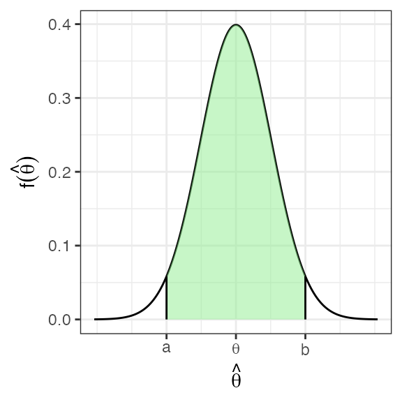

## CI construction (2)

Because $\hat{\theta}$ is normally distributed, the shortest interval $[a,b]$ that will contain $\hat{\theta}$ 95% of the time is
$$[\theta - 1.96 \sigma, \theta + 1.96 \sigma]$$

For 90% interval,
$$[\theta - 1.64 \sigma, \theta + 1.64 \sigma]$$

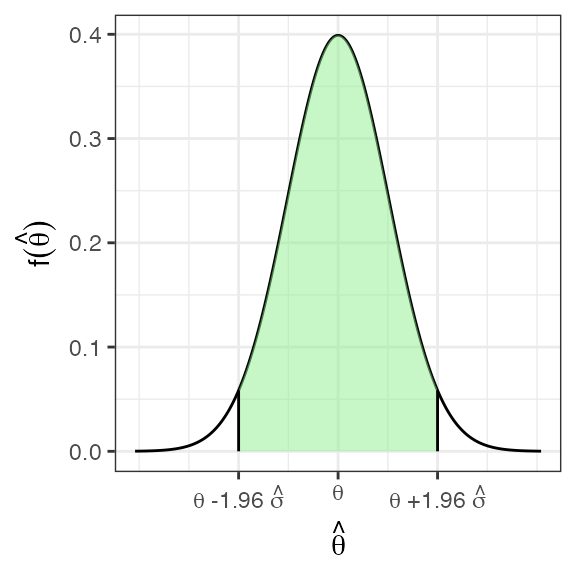

## Where do these numbers come from?

```r
# -1.96 is the value of a standard normal
# i.e. N(0, 1)
# that is above 2.5% of mass
pnorm(q = -1.96, mean = 0, sd = 1)
```

```
[1] 0.0249979
```

```r
# what if not standardized?
me <- -.345
st <- 1.23
pnorm(q = me - 1.96*st, mean = me, sd = st)
```

```
[1] 0.0249979
```

```r
# so 95% is between these
pnorm(q = 1.96) - pnorm(q = -1.96) # std normal
```

```
[1] 0.9500042
```

```r
pnorm(me + 1.96*st, mean = me, sd = st) -
  pnorm(me - 1.96*st, mean = me, sd = st)
```

```
[1] 0.9500042
```

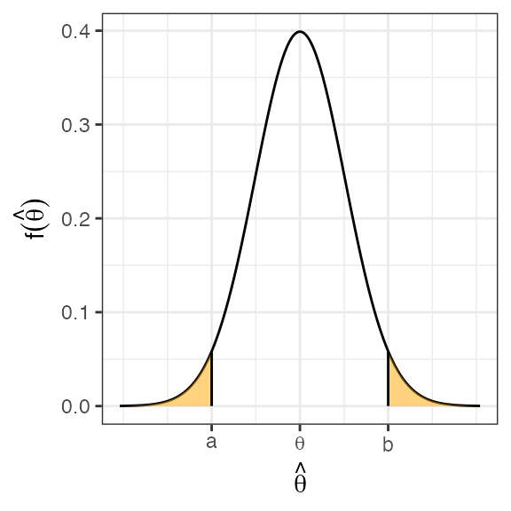

## Demonstration

Everyone use `R` to draw a single value from normal distribution with mean 4 and sd 2.

What proportion of draws are

- outside the interval $[4 - 1.96 \times 2, 4 + 1.96 \times 2] = [0.08, 7.92]$?
- outside the interval $[4 - 1.64 \times 2, 4 + 1.64 \times 2] = [.72, 7.28]$?

## CI construction (3)

We have an interval that contains 95% of $\hat{\theta}$ draws, given $\theta$ and $\sigma$.

We want an interval that contains $\theta$ 95% of the time, given $\hat{\theta}$ and $\hat{\sigma}$.

Consider this interval:

$$\left[ \hat{\theta} - 1.96 \hat{\sigma}, \hat{\theta} + 1.96 \hat{\sigma} \right]$$

We can construct it without knowing $\theta$, and (asymptotically) it contains $\theta$ 95% of the time!

## CI construction (4)

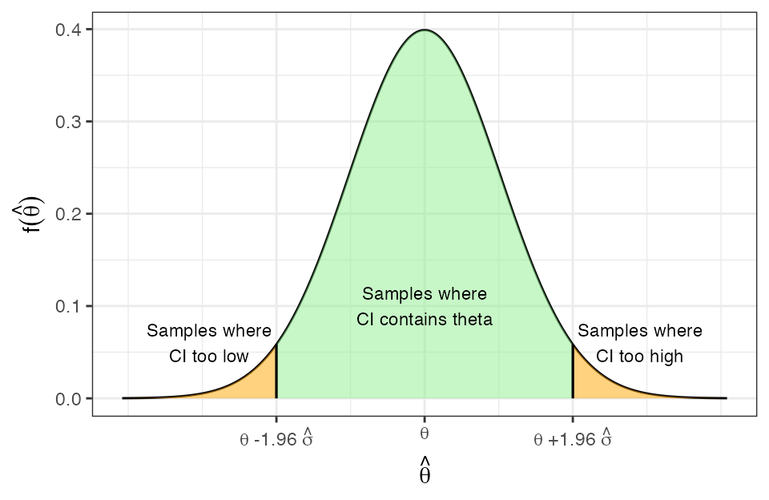

## Demonstration 2

Everyone use `R` to draw a sample of size $n=400$ from normal distribution with mean 4 and sd 2. Using your sample, make a 90% confidence interval for the population mean:

- get $\hat{\theta}$ and $\hat{\sigma}$
- make $\left[ \hat{\theta} - 1.64 \hat{\sigma}, \hat{\theta} + 1.64 \hat{\sigma} \right]$

Does your CI include $4$ (the population mean)?

## Demonstration 2 (code)

```r
samp <- rnorm(n = 400, mean = 4, sd = 2)
hat_theta <- mean(samp)
hat_sigma <- sd(samp)/sqrt(400)  # = sqrt(var(samp)/400)
# lower bound
hat_theta - 1.64*hat_sigma
```

```
[1] 3.891612
```

```r
# upper bound
hat_theta + 1.64*hat_sigma
```

```
[1] 4.218573
```

## Illustration: 90% confidence interval

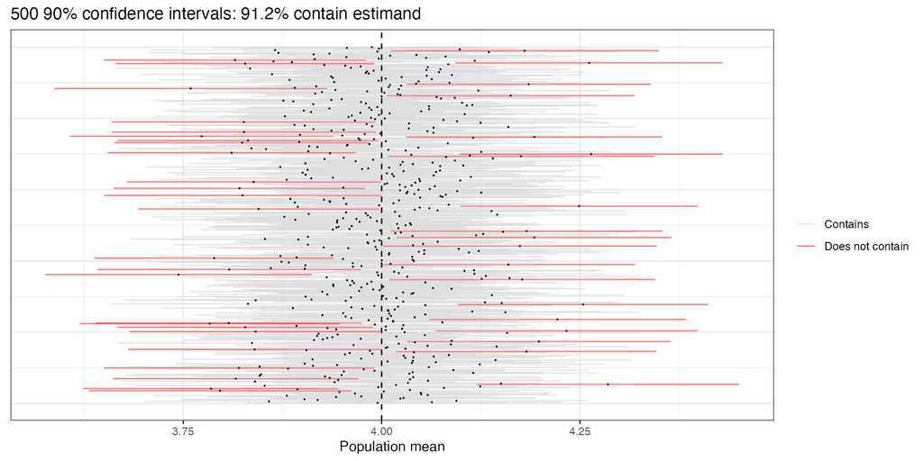

## Illustration: 99% confidence interval

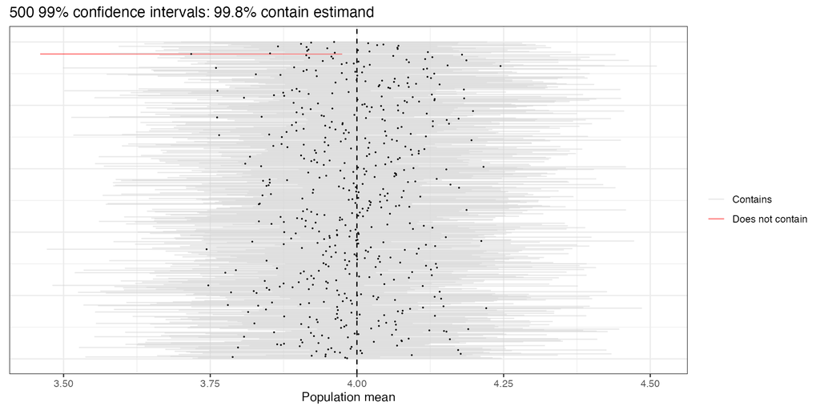

## Interpretation of confidence intervals

As a **frequentist** concept, the confidence interval is about a long-run average: if I make many 95% (valid) confidence intervals, 95% of them will contain the true value.

Recall, for a valid 95% CI $\text{Pr}(\theta \in \text{CI}) = 95\%$.

$\theta$ is not a random variable; this is a probability statement about the frequency of the CI including $\theta$, not your beliefs about where $\theta$ is.

But in the absence of other information, a Bayesian would say “There is a 95% probability that $\theta$ is in this CI.”

# Hypothesis testing and p-values

## Hypothesis testing: motivation

With confidence intervals, we report an interval centered on estimate $\hat{\theta}^*$ that is likely (in either frequentist or Bayesian sense) to contain the estimand $\theta$.

Another approach: **hypothesis testing**.

Basic idea:

- specify a **null hypothesis** $\theta_0$: a possible value of $\theta$ (typically one you’re arguing against)
- say how unlikely your result (or a more extreme one) would be if null hypothesis were true ($p$-value)

The more unlikely your result $\hat{\theta}^*$ would be *under the null* (i.e. the lower the $p$-value), the more doubtful the null hypothesis appears.

## The logic of hypothesis testing

Similar to **proof by contradiction** (modus tollens):

- “If $A$, then $B$; but $B$ is false, so $A$ is false.”
- “If he loved me, then he would have called; he didn’t call, so he doesn’t love me.”

But it’s a **probabilistic version** (weak syllogism):

- “If $A$, then $B$ likely; but $B$ is false, so $A$ becomes less likely”
- “If he loved me, then he *probably* would have called; the fact that he didn’t call makes me more doubtful that he loves me”

The latter conclusion is logically warranted (by Bayes’ rule) if $\text{Pr}(\text{no call} \mid \text{love}) < \text{Pr}(\text{no call} \mid \text{no love})$.

But the conclusion that “he probably doesn’t love me” is not – it depends on how confident you were of his love before.

## Bayes rule, again

We have:

$$\begin{align}
\text{Pr}[\text{love} \mid \text{no call}] &= \frac{\text{Pr}[\text{no call} \mid \text{love}] \text{Pr}[\text{love}]}{\text{Pr}[\text{no call}]}\\
\text{Pr}[\text{no love} \mid \text{no call}] &= \frac{\text{Pr}[\text{no call} \mid \text{no love}] \text{Pr}[\text{no love}]}{\text{Pr}[\text{no call}]}
\end{align}$$

The ratio between them:

$$\overbrace{\frac{\text{Pr}[\text{love} \mid \text{no call}]}{\text{Pr}[\text{no love} \mid \text{no call}]}}^{\text{Posterior odds}} = \overbrace{\frac{ \text{Pr}[\text{no call} \mid \text{love}] }{\text{Pr}[\text{no call} \mid \text{no love}] }}^{\text{Likelihood ratio}} \overbrace{\frac{\text{Pr}[\text{love}]}{\text{Pr}[\text{no love}]}}^{\text{Prior odds}}$$

Posterior odds lower than prior odds $\iff$ likelihood ratio $< 1$.

## $p$-value logic (1)

**Remember**: for large enough $n$, a plug-in estimator $\hat{\theta}$ is normally distributed around estimand $\theta$ if

- unbiased (or consistent), and
- “mild regularity conditions” hold

But we don’t know $\theta$.

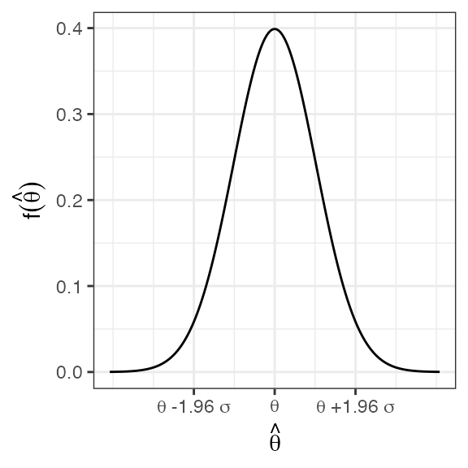

## $p$-value logic (2)

But we can say, “Suppose $\theta = \theta_0$”.

$\theta_0$ is called the *null hypothesis*. “Under the null” means “assuming $\theta = \theta_0$”.

Under the null, we have

$$\hat{\theta} \sim N(\theta_0, \hat{\sigma}^2)$$
and we can estimate the probability that $\hat{\theta}$ would be in any interval, given $\theta_0$.

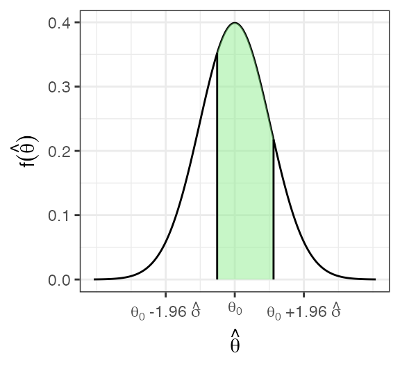

## The lower one-tailed $p$-value

Lower one-tailed p-value:

$$\text{Pr}[\hat{\theta} \leq \hat{\theta}^*]$$
under the null.

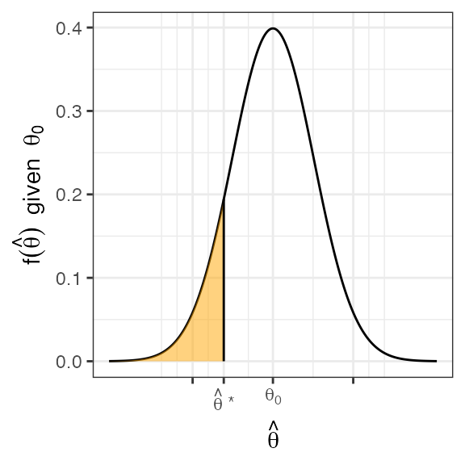

## The upper one-tailed $p$-value

Upper one-tailed p-value:

$$\text{Pr}[\hat{\theta} \geq \hat{\theta}^*]$$
under the null.

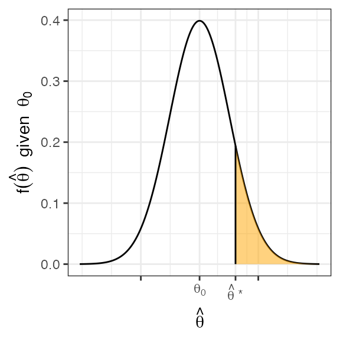

## The two-tailed $p$-value

Two-tailed p-value: $\text{Pr}\left[\lvert\hat{\theta} - \theta_0\rvert \geq \lvert\hat{\theta}^* - \theta_0\rvert \right]$ under the null.

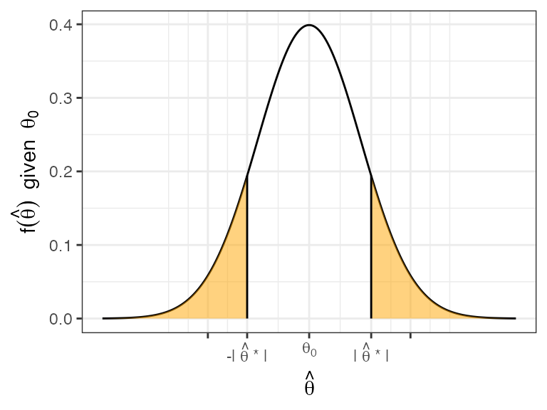

## Computing $p$-values (1)

It is useful to transform our estimate $\hat{\theta}^*$ into a $t$-statistic:

$$t = \frac{\hat{\theta}^* - \theta_0}{\sqrt{\hat{\text{V}}[\hat{\theta}]}}$$

In words: the difference between the estimate and the null, divided by the standard error of the estimator.

$|t|$ gets bigger when

- estimate gets further from null, or
- estimator gets more precise

Under the null, asymptotically $t \sim N(0, 1)$.

Like $z$-score ($\frac{X - \overline{X}}{\sigma[X]}$), $t$-statistic is a standardization/normalization.

## Computing $p$-values (2)

Suppose $t^*$ (the observed $t$) is $-1.5$.

Since asymptotically $t \sim N(0, 1)$ under null hypothesis, we can compute asymptotically valid **lower one-tailed** $p$-value as follows:

```r
my_t <- -1.5
pnorm(my_t)
```

```
[1] 0.0668072
```

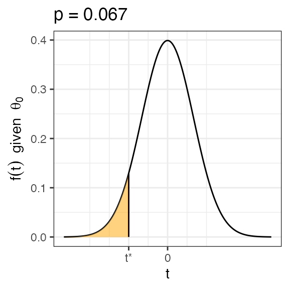

## Computing $p$-values (3)

Suppose $t^* = 1.5$.

We can compute asymptotically valid **upper one-tailed** $p$-value as follows:

```r
my_t <- 1.5
1 - pnorm(my_t)
```

```
[1] 0.0668072
```

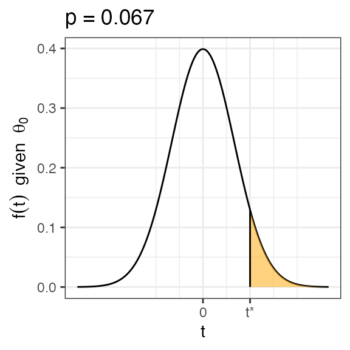

## Computing $p$-values (4)

We can compute asymptotically valid **two-tailed** $p$-value as follows:

```r
pnorm(-abs(my_t)) + 1 - pnorm(abs(my_t))
```

```
[1] 0.1336144
```

```r
2*(pnorm(-abs(my_t)))
```

```
[1] 0.1336144
```

```r
2*(1 - pnorm(abs(my_t)))
```

```
[1] 0.1336144
```

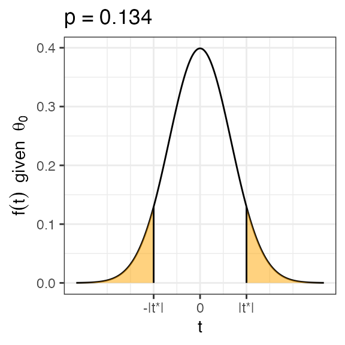

## One-tailed vs two-tailed

- **Lower one-tailed $p$-value** answers question, “How likely is it that I would get a value at least as *low* as $\hat{\theta}^*$ ($t^*$) if $\theta = \theta_0$?” (similar for upper)
- **Two-tailed $p$-value** answers question, “How likely is it that I would get a value at least as *extreme* as $\hat{\theta}^*$ ($t^*$) if $\theta = \theta_0$?”

In principle, both interesting. One-tailed especially relevant if the null hypothesis is really that $\theta \geq \theta_0$ or $\theta \leq \theta_0$

In practice, we only use one-tailed tests when the test is *pre-registered*. Otherwise two-tailed to be conservative. Why?

## Null hypothesis significance testing (NHST)

Convention (credited to Fisher) is: “Reject null hypothesis if $p < .05$.” When the null is true, rejection should occur 5% of the time.

Rejection of null hypothesis commonly interpreted (by seminar audiences, reviewers, editors, hiring committees) as “finding something”.

So researchers *really* want to reject null.

Many “best practices” are about minimizing cheating:

- corrections for multiple hypothesis tests (problem set 2)
- pre-analysis plans that specify how analysis will be run
- requirement to share data and code (replication archive)

In this context, one-tailed p-values are seen as cheating.

## Interpretation of p-values

> Intuitively, a low $p$-value means “if the null hypothesis (that $\theta = \theta_0$) were true, we would infrequently encounter a result as extreme as the one that we saw. Therefore, if we *reject* the null hypothesis (that is, if we conclude that $\theta \neq \theta_0$) based solely on how extreme the result is, then that decision will be a mistake either infrequently (if $\theta = \theta_0$) or never (if $\theta \neq \theta_0$).” (Aronow & Miller, p. 128)

So how often will it be a mistake? i.e. what is $\text{Pr}[\theta = \theta_0 \mid \text{reject}]$ (shifting to Bayesian perspective)?

Based on above, sounds like our rejections are incorrect “between infrequently ($\alpha$) and never”.

## Interpretation of p-values (2)

What is $\text{Pr}[\theta = \theta_0 \mid \text{reject}]$ (probability a rejection is a mistake)?

Use Bayes’ Rule (problem set 2):
$$\begin{align}
\text{Pr}[\theta = \theta_0 \mid \text{reject}] &= \frac{\text{Pr}[\text{reject} \mid \theta = \theta_0 ] \text{Pr}[\theta = \theta_0]}{\text{Pr}[\text{reject} \mid \theta = \theta_0 ] \text{Pr}[\theta = \theta_0] + \text{Pr}[\text{reject} \mid \theta \neq \theta_0 ] \text{Pr}[\theta \neq \theta_0]} \\
&= \frac{\alpha p_0}{ \alpha p_0 + \text{Power} (1 - p_0)}
\end{align}$$
where $\alpha = \text{Pr}[\text{reject} \mid \theta = \theta_0 ]$, $p_0 = \text{Pr}[\theta = \theta_0]$ and $\text{Power} = \text{Pr}[\text{reject} \mid \theta \neq \theta_0 ]$.

Suppose $\alpha = .05$ (standard) and $p_0 = .5$ (good chance $\theta = \theta_0$).

Then

- if Power = .8 (standard target), $\text{Pr}[\theta = \theta_0 \mid \text{reject}] \approx .06$
- if Power = .05 (very bad), $\text{Pr}[\theta = \theta_0 \mid \text{reject}] = .5$

## What is going on (1)?

Suppose 200 tests will be performed, and $\text{Pr}[\theta = \theta_0] = .5$.

**Good situation** (power = .8):

- 100 cases where $\theta = \theta_0$, with 5 rejections.
- 100 cases where $\theta \neq \theta_0$, with 80 rejections.

**Bad situation** (power = .05):

- 100 cases where $\theta = \theta_0$, with 5 rejections.
- 100 cases where $\theta \neq \theta_0$, with 5 rejections.

Then $5/10 = .5$ of the rejections were mistakes.

## What is going on (2)?

> Intuitively, … “if we *reject* the null hypothesis…based solely on how extreme the result is, then **that decision** will be a mistake either *infrequently* (if $\theta = \theta_0$) or *never* (if $\theta \neq \theta_0$).” (Aronow & Miller, p. 128; emphasis added)

If “that decision” means “rejecting the null hypothesis”, then “infrequently” is wrong:
$$\text{Pr}[\text{rejection is mistake} \mid \theta = \theta_0] = 1$$

## More on interpreting $p$-values

> Note that a high $p$-value does not offer the same guarantees for those looking to *accept* a null hypothesis and is accordingly limited in its utility for decision making. (Aronow & Miller, p. 128)

Is this true? What do we learn from a high $p$-value?

Again Bayes’ Rule says it depends on the likelihood ratio:

$$\begin{align} \frac{\text{Pr}[ \theta = \theta_0 \mid \text{high p-value}]}{\text{Pr}[ \theta = \theta_1 \mid \text{high p-value}]} &= \frac{\frac{\text{Pr}[ \text{high p-value} \mid \theta = \theta_0 ] \text{Pr}[ \theta = \theta_0 ]}{\text{Pr}[ \text{high p-value}]}}{\frac{\text{Pr}[ \text{high p-value} \mid \theta = \theta_1 ] \text{Pr}[ \theta = \theta_1 ]}{\text{Pr}[ \text{high p-value}]}} \\
&= \frac{\text{Pr}[ \text{high p-value} \mid \theta = \theta_0 ]}{\text{Pr}[ \text{high p-value} \mid \theta = \theta_1 ]} \frac{\text{Pr}[ \theta = \theta_0 ]}{\text{Pr}[ \theta = \theta_1 ]}
\end{align}$$

If a high $p$-value is much more likely under the null than when $\theta = \theta_1$, then $\theta_0$ may become much more plausible compared to $\theta_1$.

## Interpreting p-values: conclusion

- interpreting $p$-values is hard
- lower $p$-value casts more doubt on null hypothesis
- saying more (e.g. about share of rejections that are wrong, probability null is true) requires more information
- use Bayes’ rule

# The bootstrap

## Bootstrap motivation

We know that plug-in estimators $\hat{\theta}$ are normally distributed (under mild regularity conditions).

In many cases we can prove unbiasedness (${\textrm E}[\hat{\theta}] = \theta$) or consistency ($\hat{\theta} \rightarrow \theta$) (e.g. sample variance)

But what about the variance ${\textrm V}[\hat{\theta}]$? (necessary for CIs, $p$-values)

We proved that ${\textrm V}[\overline{X}] = \frac{{\textrm V}[X]}{n}$ given iid samples, but what about

- other estimands/estimators?
- non iid samples?

**Example:** correlation between two variables, ratio of two means

The **bootstrap** is a very general solution for estimating ${\textrm V}[\hat{\theta}]$.

## Bootstrap basics

${\textrm V}[\hat{\theta}]$ describes the variance of $\hat{\theta}$ across samples of size $n$.

**Problem:** We have only one sample of size $n$.

**Bootstrap solution:**

- Generate $m$ artificial samples of size $n$ by **resampling** from our sample *with replacement*
- Estimate ${\textrm V}[\hat{\theta}]$ using the variance of $\hat{\theta}$ across these artificial samples

## Bootstrap illustration

```r
samp <- c(4,2,5,3,6,6)
mean(samp)
```

```
[1] 4.333333
```

```r
(resamp1 <- sample(samp, size = length(samp), replace = T))
```

```
[1] 6 3 5 2 3 3
```

```r
mean(resamp1)
```

```
[1] 3.666667
```

```r
(resamp2 <- sample(samp, size = length(samp), replace = T))
```

```
[1] 4 6 5 6 6 3
```

```r
mean(resamp2)
```

```
[1] 5
```

```r
(resamp3 <- sample(samp, size = length(samp), replace = T))
```

```
[1] 6 2 3 6 2 4
```

```r
mean(resamp3)
```

```
[1] 3.833333
```

## Bootstrap illustration (2)

```r
m <- 1000
sto <- rep(NA, times = m)
for(i in 1:m){
  resamp <- sample(samp, size = length(samp), replace = T)
  sto[i] <- mean(resamp)
}
```

```r
# these are our simulated sample means
head(sto)
```

```
[1] 4.166667 3.833333 4.333333 4.666667 4.000000 2.833333
```

```r
# our bootstrap estimate of the variance of the sample mean:
var(sto)
```

```
[1] 0.3817928
```

```r
# our bootstrap estimate of the standard error (of the sample mean):
sd(sto)
```

```
[1] 0.6178938
```

## Does this work? (And if so why?)

The bootstrap is a **plug-in estimator**!

- Our estimand is ${\textrm V}[\hat{\theta}]$, the sampling variance
- If we had the population, we could compute ${\textrm V}[\hat{\theta}]$ by resampling from population
- We don’t have the population, so we “plug in” the sample and resample from that
- As $n$ increases, the sample looks more like the population, so the bootstrap estimate of ${\textrm V}[\hat{\theta}]$ gets closer to the estimand

Compare to our approach to estimating ${\textrm V}[\overline{X}]$ previously:

- Analytically determine that ${\textrm V}[\overline{X}] = \frac{{\textrm V}[X]}{n}$
- Use plug-in principle to estimate ${\textrm V}[X]$: compute `var()` in sample instead of population

We don’t need bootstrap for $V[\overline{X}]$, but it will work for (almost) *anything*.

## Bootstrap example

```r
dat <- read.csv("./../data/cces_2012_subset.csv")
```

Earlier, we learned this approach to estimating $\sigma[\overline{X}]$:

```r
std_error <- sqrt(var(dat$env, na.rm = T)/sum(!is.na(dat$env)))
std_error
```

```
[1] 0.01406871
```

This also works:

```r
env <- dat$env[!is.na(dat$env)]
sd(env)/sqrt(length(env))
```

```
[1] 0.01406871
```

The bootstrap approach:

- resample $n$ rows with replacement from `dat` $m$ times
- compute $m$ sample means
- compute standard deviation across them

## Bootstrap example (2)

I stored $m=1000$ sample means in `samp_means`.

```r
(bootstrap_std_error <- sd(samp_means))
```

```
[1] 0.01422936
```

Very close to other solution!

```r
# using "analytical" approach (V[X]/n)
mean(dat$env, na.rm = T) + 1.96*std_error*c(-1, 1)
```

```
[1] 3.168247 3.223397
```

```r
# using bootstrap
mean(dat$env, na.rm = T) + 1.96*bootstrap_std_error*c(-1, 1)
```

```
[1] 3.167932 3.223711
```

## Using the bootstrap

**Our estimand** $\theta$: correlation between `env` and `aa` in 2012 CCES (CCES is population)

**Our estimator** $\hat{\theta}$: correlation in a sample of $n$ rows

**Variance of our estimator** ${\textrm V}[\hat{\theta}]$:

- True value can be approximated by repeated samples from population
- How to estimate from sample:
  - Analytical solution (analogous to ${\textrm V}[X]/n$ for sample mean)?
  - Bootstrap!

## Application of bootstrap (2)

1. *Repeated samples from population*: draw 5000 samples of size **500** from full CCES; compute `cor(env, aa)` in each one
2. *Repeated resamples from sample*: start with sample of size **500** from CCES; draw 5000 resamples; compute `cor(env, aa)` in each one

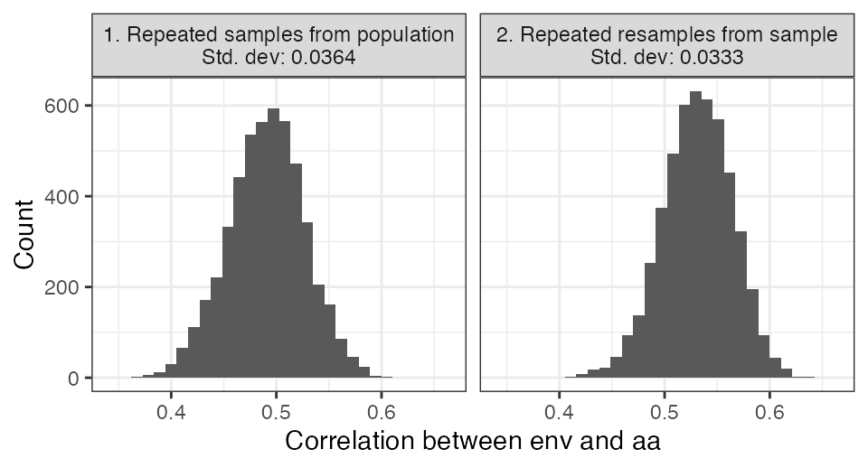

## Application of bootstrap (2)

1. *Repeated samples from population*: draw 5000 samples of size **1500** from full CCES; compute `cor(env, aa)` in each one
2. *Repeated resamples from sample*: start with sample of size **1500** from CCES; draw 5000 resamples; compute `cor(env, aa)` in each one

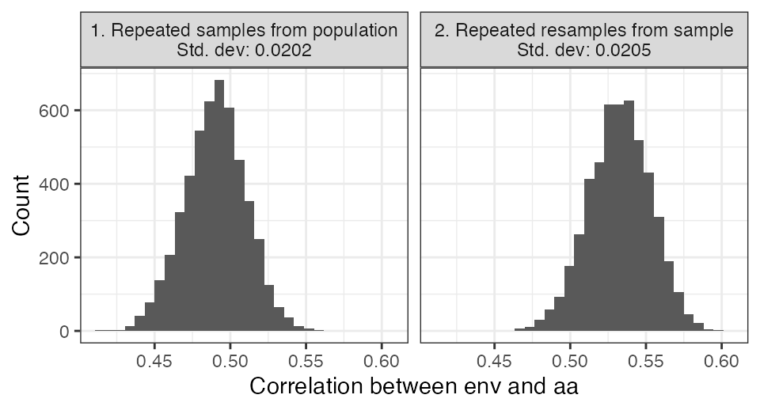

## Varieties of bootstrap

**Naive bootstrap**: Resample rows of the dataset with replacement (i.e. the method above).

**Block bootstrap**: For grouped data (e.g. students in schools), resample groups rather than dataset rows

**Bayesian bootstrap**: Keep rows of dataset same but draw random **reweightings**

**Residual bootstrap**: Keep rows of dataset same but resample *residuals*, i.e.

- Fit a model for $Y$
- Compute *fitted value* $\hat{y}_i$ and *residual* $\hat{e}_i$ for each observation, where $y_i = \hat{y}_i + \hat{e}_i$
- Resample residuals with replacement, so $y_i$ becomes $\hat{y}_i + \hat{e}_j$

**Wild bootstrap** (unrestricted): Keep rows of dataset same but *rescale residuals*, e.g. by draws from $\{-1, 1\}$ (equal probability) or $N(0, 1)$

# Randomization inference

## Motivation

So far, we have focused on uncertainty that comes from *sampling from a population*: we don’t know about the units not in the sample.

- **Target of inference**: Population quantity (e.g. population average, regression coefficient)
- **Source of uncertainty**: Missing rows

In causal inference, we also care about uncertainty that comes from the *assignment of treatment*: we don’t know some of the *potential outcomes*, i.e. outcomes for a given unit if it had each treatment

- **Target of inference**: Sample quantity (e.g. sample average treatment effect)
- **Source of uncertainty**: Missing data (missing potential outcomes)

## Randomization inference: procedure

**Sharp null hypothesis** is that treatment does not affect outcomes.

Under sharp null, we **do** know the missing potential outcomes: they are the same as observed potential outcomes.

So:

- randomly reshuffle the treatment – e.g. instead of `1, 1, 0, 1, 0, 0` (actual treatments ), use `1, 0, 0, 1, 1, 0`
- compute “treatment effect” under sharp null
- store and repeat

Get a $p$-value by comparing observed treatment effect to distribution of treatment effects under sharp null.

## Randomization inference example

Green, Gerber, and Larimer assign households to receive GOTV fliers or not.

```
# A tibble: 6 × 3
  treatment hh_size voted
  <fct>       <int> <dbl>
1 Control         2     0
2 Control         2     1
3 Control         2     0
4 CivicDuty       2     0
5 CivicDuty       2     1
6 CivicDuty       2     0
```

Turnout rate by type of household:

```r
(treat_mean <- mean(d2$voted[d2$treatment == "CivicDuty"]))
```

```
[1] 0.3249221
```

```r
(control_mean <- mean(d2$voted[d2$treatment == "Control"]))
```

```
[1] 0.304307
```

```r
(true_diff <- treat_mean - control_mean)
```

```
[1] 0.02061504
```

## Randomization inference example (2)

What is the probability of getting a turnout difference as big as 0.021 if the treatment has no effect on any household?

```r
m <- 1000; sto <- 1:m; d3 <- d2
for(i in 1:m){
  d3$voted <- sample(d3$voted)
  sto[i] <- mean(d3$voted[d3$treatment == "CivicDuty"]) -
mean(d3$voted[d3$treatment == "Control"])
}
```

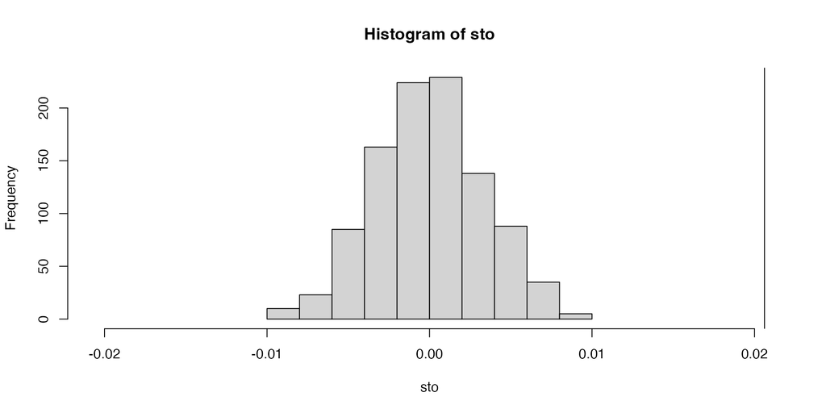

```r
mean(abs(sto) > true_diff)
```

```
[1] 0
```

## Inference wrap-up

If we are going to report measures of uncertainty, we need to specify what is uncertain.

Our focus was on *sampling* from a population – the most straightforward.

In randomization inference, we focused on *treatment assignment* as another source of uncertainty.

In most social science research, source of uncertainty not specified, but could be

- sampling from a *super-population*: there could have been other OECDs out there!
- model-based uncertainty – treat the error term as random, e.g. due to measurement error or other unknown factors